# Statistical Learning Project - Unsupervised Learning

```r
#https://www.kaggle.com/dgomonov/new-york-city-airbnb-open-data
library(ggplot2)
library(ggmap)
library(tidyr)
library(cowplot)
library(magick)
library(dplyr)
#world_map <- map_data("newyork")
```

# Read Dataset

```r
ds = read.csv("AB_NYC_2019.csv")
head(ds)
```

```
##     id                                             name host_id   host_name
## 1 2539               Clean & quiet apt home by the park    2787        John
## 2 2595                            Skylit Midtown Castle    2845    Jennifer
## 3 3647              THE VILLAGE OF HARLEM....NEW YORK !    4632   Elisabeth
## 4 3831                  Cozy Entire Floor of Brownstone    4869 LisaRoxanne
## 5 5022 Entire Apt: Spacious Studio/Loft by central park    7192       Laura
## 6 5099        Large Cozy 1 BR Apartment In Midtown East    7322       Chris
##   neighbourhood_group neighbourhood latitude longitude       room_type price
## 1            Brooklyn    Kensington 40.64749 -73.97237    Private room   149
## 2           Manhattan       Midtown 40.75362 -73.98377 Entire home/apt   225
## 3           Manhattan        Harlem 40.80902 -73.94190    Private room   150
## 4            Brooklyn  Clinton Hill 40.68514 -73.95976 Entire home/apt    89
## 5           Manhattan   East Harlem 40.79851 -73.94399 Entire home/apt    80
## 6           Manhattan   Murray Hill 40.74767 -73.97500 Entire home/apt   200
##   minimum_nights number_of_reviews last_review reviews_per_month
## 1              1                 9  2018-10-19              0.21
## 2              1                45  2019-05-21              0.38
## 3              3                 0                            NA
## 4              1               270  2019-07-05              4.64
## 5             10                 9  2018-11-19              0.10
## 6              3                74  2019-06-22              0.59
##   calculated_host_listings_count availability_365
## 1                              6              365
## 2                              2              355
## 3                              1              365
## 4                              1              194
## 5                              1                0
## 6                              1              129
```

# Data cleaning

## Check for NA and NULL values

```r
#Check for NA
apply(ds,2,function(x) sum(is.na(x)))
```

```
##                             id                           name
##                              0                              0
##                        host_id                      host_name
##                              0                              0
##            neighbourhood_group                  neighbourhood
##                              0                              0
##                       latitude                      longitude
##                              0                              0
##                      room_type                          price
##                              0                              0
##                 minimum_nights              number_of_reviews
##                              0                              0
##                    last_review              reviews_per_month
##                              0                          10052
## calculated_host_listings_count               availability_365
##                              0                              0
```

```r
# NOTES
# Remove NA, empty
#
#
#
#
```

## Normalisation and selection of the variables

```r
normalize <- function(x) {
  return ((x - min(x)) / (max(x) - min(x)))
}


clean_data = function(ds)
{
  ds = select (ds,-c(host_id, id, host_name, name,minimum_nights,number_of_reviews,
                     neighbourhood,last_review,availability_365,

                     reviews_per_month,calculated_host_listings_count))


  numerical = c("price","longitude", "latitude")
  categorical = c("neighbourhood_group")

  ds[numerical] = scale(ds[numerical])
  ds$neighbourhood_group = factor(ds$neighbourhood_group,
                                  level= c("Brooklyn","Manhattan",
                                           "Queens","Staten Island", "Bronx"),
                                  labels=c(1,2,3,4,5))
  ds$room_type = factor(ds$room_type,
                        level= c("Private room","Entire home/apt","Shared room"),
                        labels=c(1,2,3))

  return(ds)
}
#ggdraw() +
#  draw_image("New_York_City_.png") +
#  draw_plot(myplot)

dataset = clean_data(ds)

head(dataset)
```

```
##   neighbourhood_group   latitude  longitude room_type       price
## 1                   1 -1.4938339 -0.4376476         1 -0.01549291
## 2                   2  0.4524314 -0.6846321         2  0.30097047
## 3                   2  1.4683845  0.2224944         1 -0.01132892
## 4                   1 -0.8033893 -0.1644481         2 -0.26533242
## 5                   2  1.2756468  0.1772139         2 -0.30280835
## 6                   2  0.3433173 -0.4946274         2  0.19687067
```

# K-MEANS

**x**: numeric matrix, numeric data frame or a numeric vector **centers**: Possible values are the number of clusters (k) or a set of initial (distinct) cluster centers. If a number, a random set of (distinct) rows in x is chosen as the initial centers. **iter.max**: The maximum number of iterations allowed. Default value is 10. **nstart**: The number of random starting partitions when centers is a number. Trying nstart > 1 is often recommended.

```r
km.res = kmeans(dataset, 4, nstart = 25)

cat("First 10 Clusters association",km.res$cluster[1:10])
```

```
## First 10 Clusters association 1 2 2 1 2 2 1 2 2 2
```

```r
cat("\nCenters")
```

```
##
## Centers
```

```r
print(km.res$centers)
```

```
##   neighbourhood_group   latitude   longitude room_type      price
## 1            1.002839 -0.8078700  0.01786529  1.515912 -0.1419676
## 2            2.051265  0.6141866 -0.51376305  1.650961  0.1253757
## 3            1.868421  0.1287874 -0.50832977  1.824561 14.7620392
## 4            3.346637  0.3881026  1.78314575  1.427095 -0.2611466
```

```r
cat("\ntotss",km.res$totss)
```

```
##
## totss 195866.3
```

```r
cat("\nwithinss",km.res$withinss)
```

```
##
## withinss 21164.81 39332.74 9312.047 22019.68
```

```r
cat("\ntot_withinss",km.res$tot.withinss)
```

```
##
## tot_withinss 91829.28
```

```r
cat("\nbetweenss",km.res$betweenss)
```

```
##
## betweenss 104037.1
```

```r
cat("\nSize",km.res$size)
```

```
##
## Size 20079 22413 114 6289
```

```r
cat("\niter",km.res$iter)
```

```
##
## iter 3
```

```r
cat("\nifault",km.res$ifault)
```

```
##
## ifault 0
```

```r
library(factoextra)
```

Cluster number for each of the observations

```r
head(km.res$cluster)
```

```
## [1] 1 2 2 1 2 2
```

Cluster size

```r
km.res$size
```

```
## [1] 20079 22413   114  6289
```

Cluster means

```r
km.res$centers
```

```
##   neighbourhood_group   latitude   longitude room_type      price
## 1            1.002839 -0.8078700  0.01786529  1.515912 -0.1419676
## 2            2.051265  0.6141866 -0.51376305  1.650961  0.1253757
## 3            1.868421  0.1287874 -0.50832977  1.824561 14.7620392
## 4            3.346637  0.3881026  1.78314575  1.427095 -0.2611466
```

```r
#dataset$neighbourhood_group = as.numeric( dataset$neighbourhood_group)
#dataset$room_type = as.numeric(  dataset$room_type)
#fviz_cluster(km.res, data = dataset,
#             palette = c("#00AFBB","#2E9FDF", "#E7B800", "#FC4E07"),
#             ggtheme = theme_minimal(),
#             main = "Partitioning Clustering Plot"
#)

#res <- hcut(dataset, k = 4, stand = FALSE)
#fviz_dend(km.res, rect = TRUE, cex = 0.5,
#          k_colors = c("#00AFBB","#2E9FDF", "#E7B800", "#FC4E07"))
```

# Partitioning Around Medoids (PAM) ALGORITHM

https://dpmartin42.github.io/posts/r/cluster-mixed-types

https://towardsdatascience.com/clustering-on-mixed-type-data-8bbd0a2569c3

```r
library(cluster)
library(readr)
library(Rtsne)
```

Compute Gower distance

```r
dim(dataset)
```

```
## [1] 48895     5
```

```r
reduced <- dataset[ sample(1:nrow(dataset), nrow(dataset)/5) , ]

print(dim(reduced))
```

```
## [1] 9779    5
```

```r
gower_dist <- daisy(reduced, metric = "gower")
#proxy::simil(reduced, method = "gower")
dim(gower_dist)
```

[output not shown]

```r
hc1 <- hclust(gower_dist, method = "complete" )
hc1
```

```
##
## Call:
## hclust(d = gower_dist, method = "complete")
##
## Cluster method   : complete
## Number of objects: 9779
```

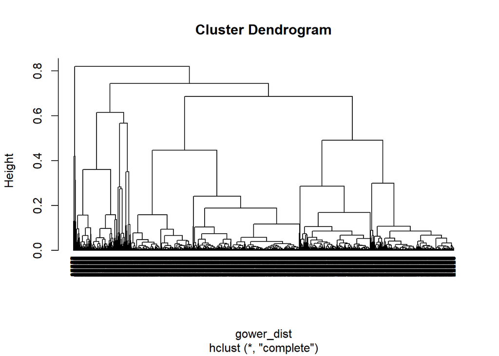

```r
plot(hc1, cex = 0.6, hang = -1)
```

```r
start.time <- Sys.time()
sil_width <- c(NA)
for(i in 2:8){
  pam_fit <- pam(gower_dist, diss = TRUE, k = i)
  sil_width[i] <- pam_fit$silinfo$avg.width
}


end.time <- Sys.time()
time.taken <- end.time - start.time

print("-- Time: -- ")
```

```
## [1] "-- Time: -- "
```

```r
time.taken
```

```
## Time difference of 5.766041 mins
```

```r
print("")
```

```
## [1] ""
```

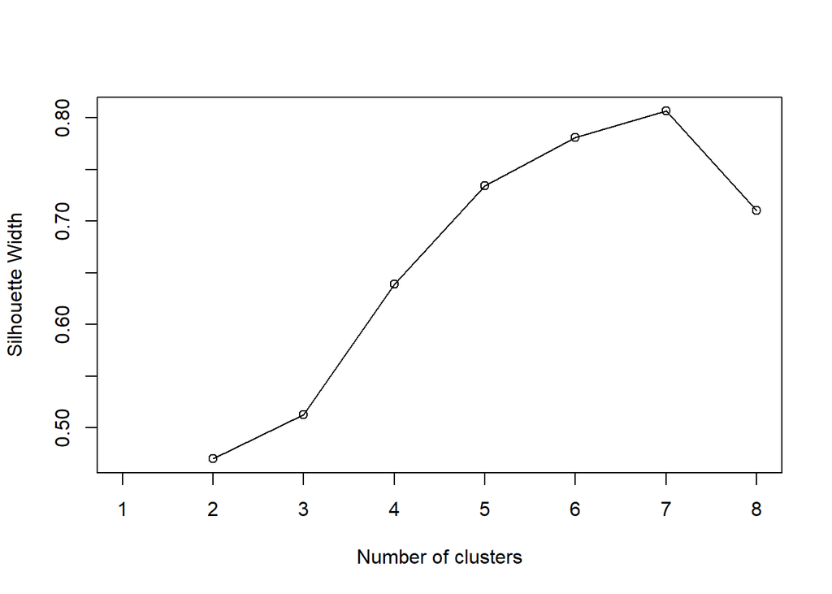

```r
plot(1:8, sil_width,
      xlab = "Number of clusters",
      ylab = "Silhouette Width")
lines(1:8, sil_width)
```

# FAMD

http://www.sthda.com/english/articles/31-principal-component-methods-in-r-practical-guide/115-famd-factor-analysis-of-mixed-data-in-r-essentials/ https://nextjournal.com/pc-methods/calculate-pc-mixed-data https://cran.r-project.org/web/packages/FactoMineR/index.html https://stats.stackexchange.com/questions/5774/can-principal-component-analysis-be-applied-to-datasets-containing-a-mix-of-cont

```r
library("FactoMineR")
library("factoextra")
```

FAMD (base, ncp = 5, sup.var = NULL, ind.sup = NULL, graph = TRUE) - base : a data frame with n rows (individuals) and p columns (variables). - ncp: the number of dimensions kept in the results (by default 5) - sup.var: a vector indicating the indexes of the supplementary variables. - ind.sup: a vector indicating the indexes of the supplementary individuals. - graph : a logical value. If TRUE a graph is displayed.

```r
res.famd <- FAMD(dataset, graph = FALSE, ncp = 10)
print(res.famd)
```

```
## *The results are available in the following objects:
##
##   name          description
## 1 "$eig"        "eigenvalues and inertia"
## 2 "$var"        "Results for the variables"
## 3 "$ind"        "results for the individuals"
## 4 "$quali.var"  "Results for the qualitative variables"
## 5 "$quanti.var" "Results for the quantitative variables"
```

```r
eig.val <- get_eigenvalue(res.famd)
head(eig.val)
```

```
##       eigenvalue variance.percent cumulative.variance.percent
## Dim.1  1.9083514         21.20390                    21.20390
## Dim.2  1.7965387         19.96154                    41.16545
## Dim.3  1.1478319         12.75369                    53.91913
## Dim.4  1.0050505         11.16723                    65.08636
## Dim.5  0.9953729         11.05970                    76.14606
## Dim.6  0.9550886         10.61210                    86.75815
```

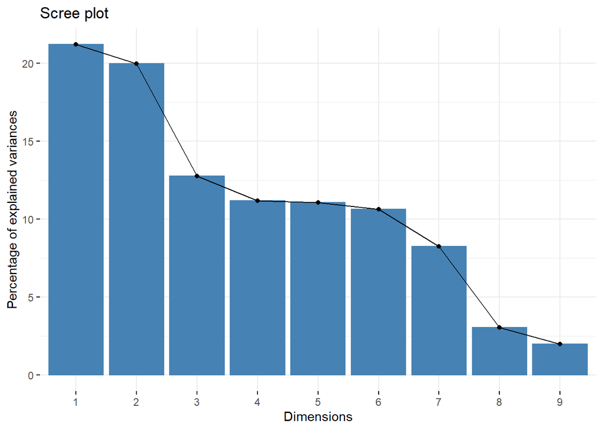

```r
fviz_screeplot(res.famd)
```

```r
var <- get_famd_var(res.famd)
var
```

```
## FAMD results for variables
##  ===================================================
##   Name       Description
## 1 "$coord"   "Coordinates"
## 2 "$cos2"    "Cos2, quality of representation"
## 3 "$contrib" "Contributions"
```

```r
# Coordinates of variables
head(var$coord)
```

```
##                           Dim.1       Dim.2      Dim.3        Dim.4
## latitude            0.005668726 0.860729171 0.02158696 0.0018259261
## longitude           0.768273453 0.036685338 0.06745104 0.0001491288
## price               0.165709524 0.014567345 0.35944780 0.0037085243
## neighbourhood_group 0.765050694 0.879653699 0.36770424 0.5237552993
## room_type           0.203649039 0.004903112 0.33164184 0.4756116022
##                            Dim.5       Dim.6        Dim.7        Dim.8
## latitude            0.0019154629 0.003930557 0.0000506023 0.0493498501
## longitude           0.0002197538 0.008388009 0.0001256024 0.0813702360
## price               0.0007848939 0.094840306 0.3603486673 0.0005451346
## neighbourhood_group 0.4843412232 0.752083689 0.0029420277 0.1399706182
## room_type           0.5081115792 0.095846006 0.3782054805 0.0019275611
##                            Dim.9
## latitude            5.494275e-02
## longitude           3.733744e-02
## price               4.780074e-05
## neighbourhood_group 8.449851e-02
## room_type           1.037779e-04
```

```r
# Cos2: quality of representation on the factore map
head(var$cos2)
```

```
##                            Dim.1        Dim.2        Dim.3        Dim.4
## latitude            3.213445e-05 7.408547e-01 0.0004659967 3.334006e-06
## longitude           5.902441e-01 1.345814e-03 0.0045496430 2.223941e-08
## price               2.745965e-02 2.122075e-04 0.1292027236 1.375315e-05
## neighbourhood_group 1.463256e-01 1.934477e-01 0.0338016020 6.857990e-02
## room_type           2.073647e-02 1.202025e-05 0.0549931561 1.131032e-01
##                            Dim.5        Dim.6        Dim.7        Dim.8
## latitude            3.668998e-06 1.544927e-05 2.560593e-09 2.435408e-03
## longitude           4.829174e-08 7.035869e-05 1.577595e-08 6.621115e-03
## price               6.160584e-07 8.994684e-03 1.298512e-01 2.971717e-07
## neighbourhood_group 5.864661e-02 1.414075e-01 2.163882e-06 4.897943e-03
## room_type           1.290887e-01 4.593228e-03 7.151969e-02 1.857746e-06
##                            Dim.9
## latitude            3.018706e-03
## longitude           1.394084e-03
## price               2.284911e-09
## neighbourhood_group 1.785000e-03
## room_type           5.384925e-09
```

```r
# Contributions to the  dimensions
head(var$contrib)
```

```
##                          Dim.1      Dim.2     Dim.3       Dim.4       Dim.5
## latitude             0.2970483 47.9104173  1.880672  0.18167507  0.19243671
## longitude           40.2584890  2.0420010  5.876387  0.01483794  0.02207754
## price                8.6833861  0.8108562 31.315370  0.36898885  0.07885426
## neighbourhood_group 40.0896124 48.9638056 32.034677 52.11233758 48.65927301
## room_type           10.6714641  0.2729199 28.892893 47.32216056 51.04735849
##                          Dim.6        Dim.7      Dim.8       Dim.9
## latitude             0.4115384  0.006822729 18.0660550 31.05333423
## longitude            0.8782441  0.016935020 29.7881180 21.10291050
## price                9.9300012 48.585962882  0.1995635  0.02701671
## neighbourhood_group 78.7449160  0.396674831 51.2406194 47.75808388
## room_type           10.0353003 50.993604537  0.7056440  0.05865468
```

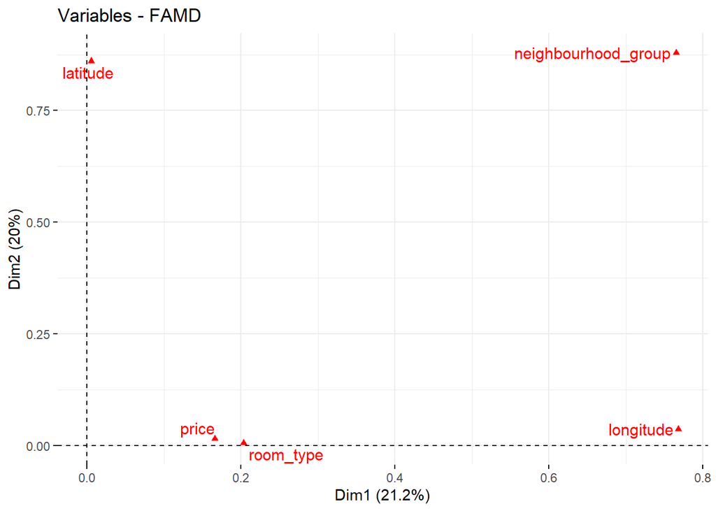

```r
# Plot of variables
fviz_famd_var(res.famd, repel = TRUE)
```

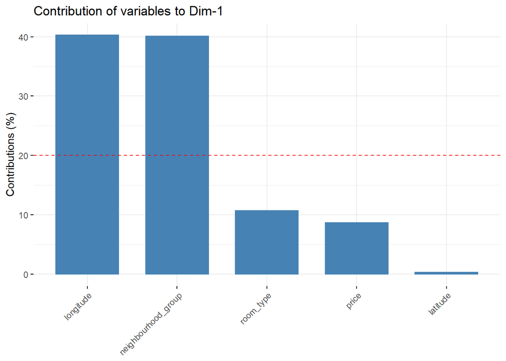

```r
# Contribution to the first dimension
fviz_contrib(res.famd, "var", axes = 1)
```

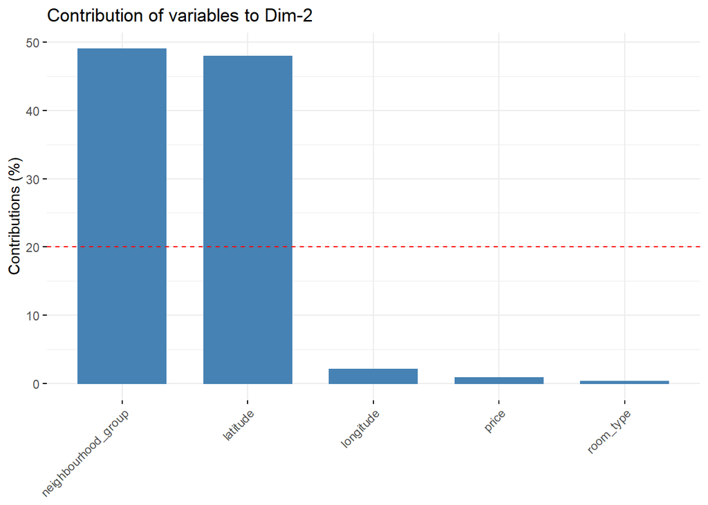

```r
# Contribution to the second dimension
fviz_contrib(res.famd, "var", axes = 2)
```

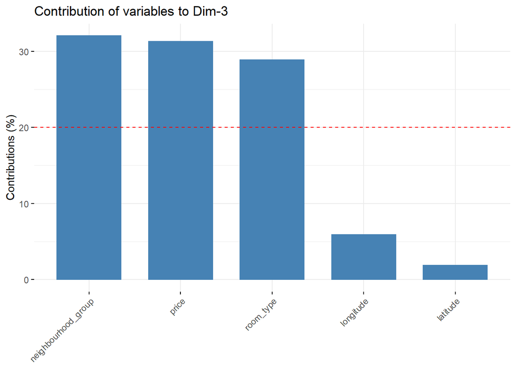

```r
# Contribution to the third dimension
fviz_contrib(res.famd, "var", axes = 3)
```

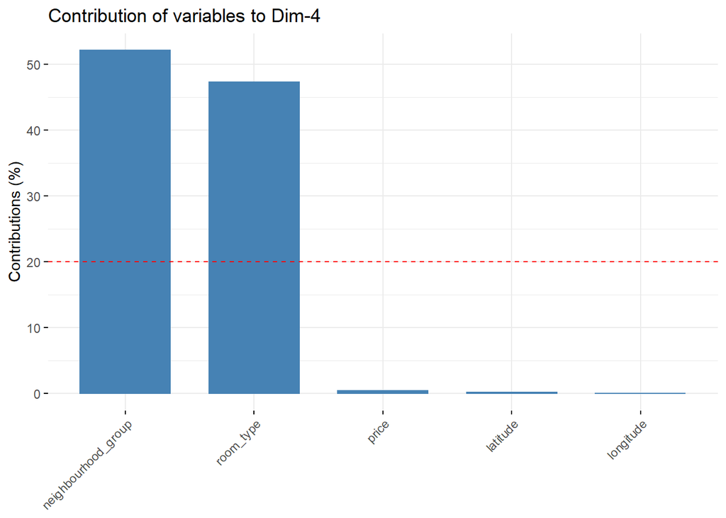

```r
# Contribution to the forth dimension
fviz_contrib(res.famd, "var", axes = 4)
```

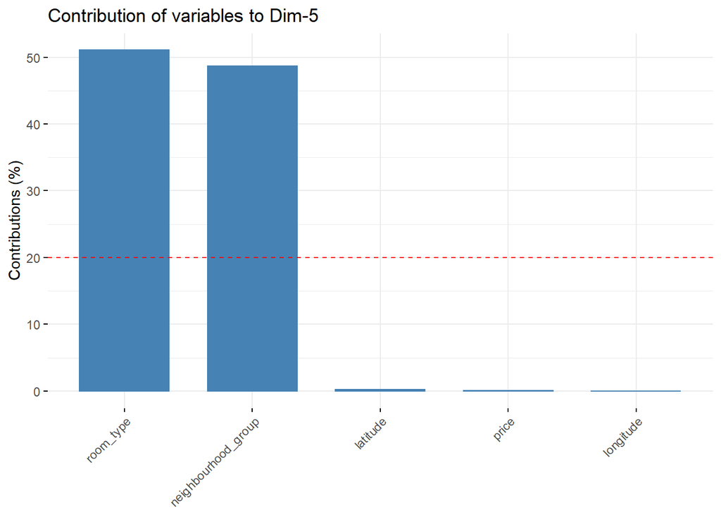

```r
# Contribution to the fifth dimension
fviz_contrib(res.famd, "var", axes = 5)
```

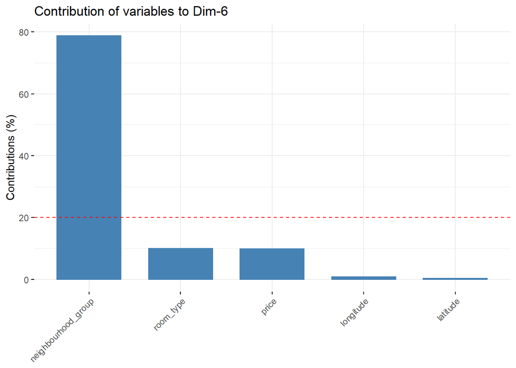

```r
# Contribution to the sixth dimension
fviz_contrib(res.famd, "var", axes = 6)
```

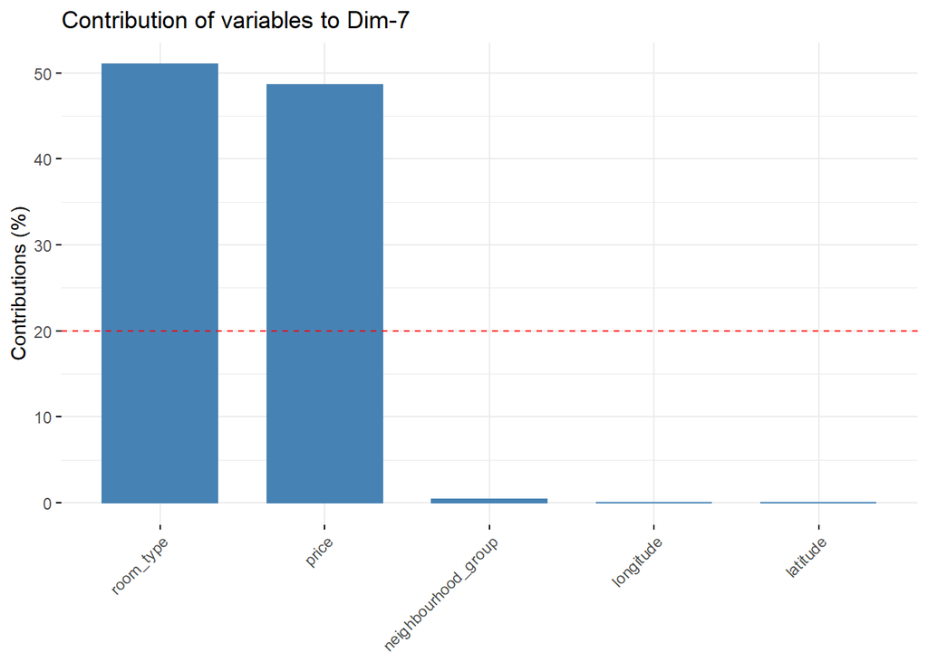

```r
# Contribution to the seventh dimension
fviz_contrib(res.famd, "var", axes = 7)
```

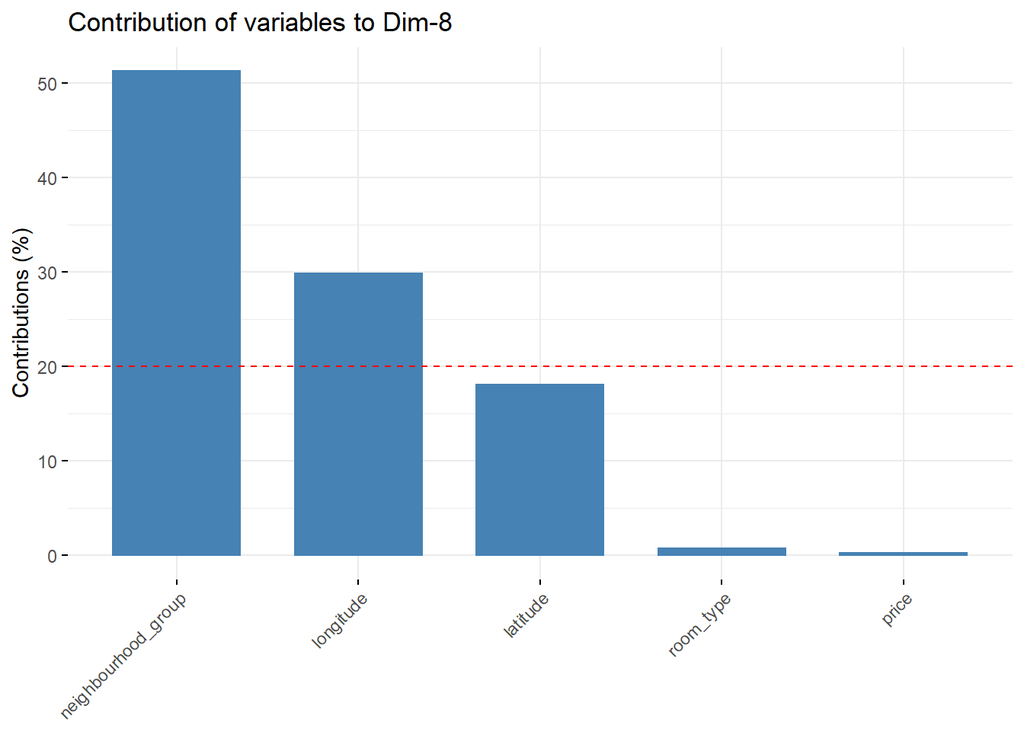

```r
# Contribution to the eighth dimension
fviz_contrib(res.famd, "var", axes = 8)
```

# PCAmixdata

```r
## Import library
library(PCAmixdata)
```

```r
## Split mixed dataset into quantitative and qualitative variables
## For now excluding the target variable "Churn", which will be added later as a supplementary variable
split <- splitmix(dataset[1:5])

## PCA
res.pcamix <- PCAmix(X.quanti=split$X.quanti,
                     X.quali=split$X.quali,
                     rename.level=TRUE,
                     graph=FALSE,
                     ndim=25)

res.pcamix
```

```
##
## Call:
## PCAmix(X.quanti = split$X.quanti, X.quali = split$X.quali, ndim = 25,     rename.level = TRUE, graph = FALSE)
##
## Method = Principal Component of mixed data (PCAmix)
##
##
## "name" "description"
## "$eig" "eigenvalues of the principal components (PC) "
## "$ind" "results for the individuals (coord,contrib,cos2)"
## "$quanti" "results for the quantitative variables (coord,contrib,cos2)"
## "$levels" "results for the levels of the qualitative variables (coord,contrib,cos2)"
## "$quali" "results for the qualitative variables (contrib,relative contrib)"
## "$sqload" "squared loadings"
## "$coef" "coef of the linear combinations defining the PC"
```

```r
## Inspect principal components
res.pcamix$eig
```

```
##       Eigenvalue Proportion Cumulative
## dim 1  1.9083514  21.203905   21.20390
## dim 2  1.7965387  19.961541   41.16545
## dim 3  1.1478319  12.753688   53.91913
## dim 4  1.0050505  11.167228   65.08636
## dim 5  0.9953729  11.059699   76.14606
## dim 6  0.9550886  10.612095   86.75815
## dim 7  0.7416724   8.240804   94.99896
## dim 8  0.2731634   3.035149   98.03411
## dim 9  0.1769303   1.965892  100.00000
```

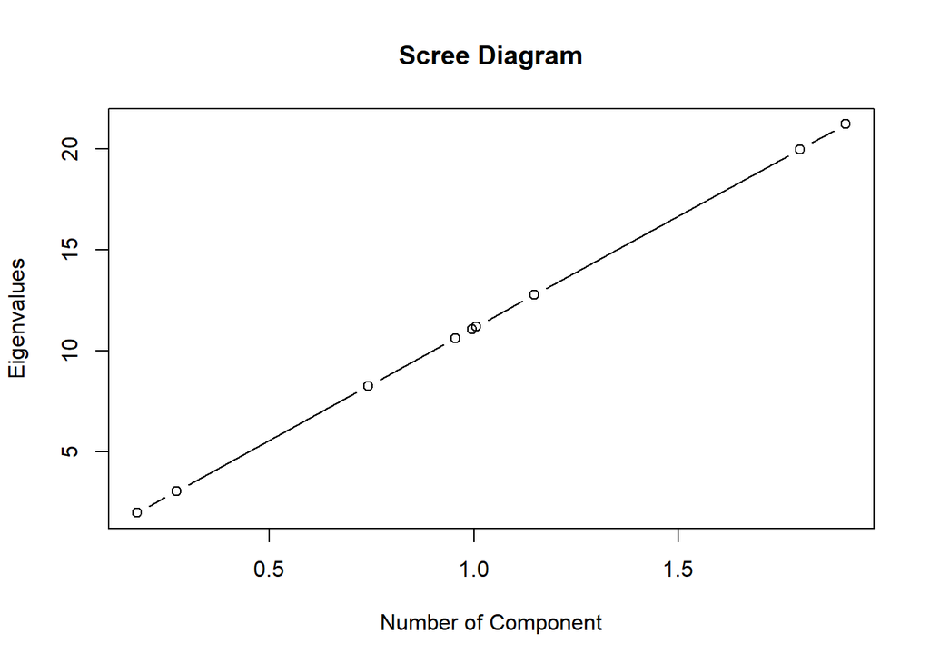

```r
# Use Scree Diagram to select the components:
plot(res.pcamix$eig, type="b", main="Scree Diagram", xlab="Number of Component", ylab="Eigenvalues")
abline(h=1, lwd=3, col="red")
```

# Hierarchical Cluster Analysis

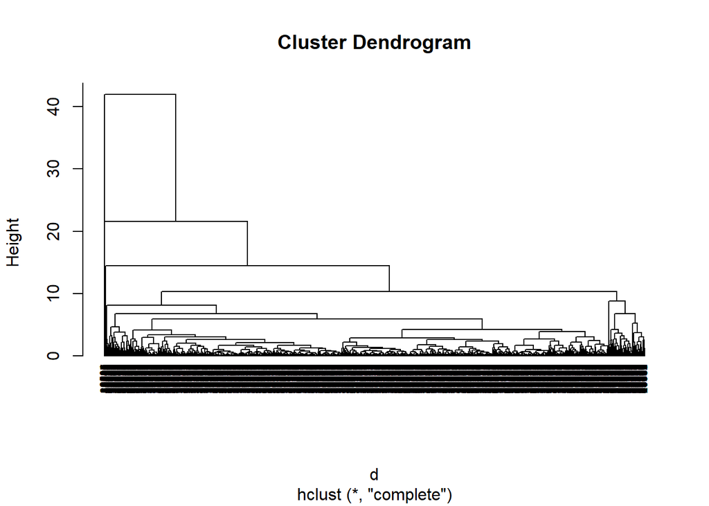

```r
library(cluster)    # clustering algorithms
library(dendextend) # for comparing two dendrograms
reduced <- dataset[ sample(1:nrow(dataset), nrow(dataset)/10 ) , ]
d <- dist(reduced, method = "euclidean")


# Hierarchical clustering using Complete Linkage
hc1 <- hclust(d, method = "complete" )

# Plot the obtained dendrogram
plot(hc1, cex = 0.6, hang = -1)
```

```r
# methods to assess
#m <- c( "average", "single", "complete", "ward")
#names(m) <- c( "average", "single", "complete", "ward")

# function to compute coefficient
#ac <- function(x) {
#  agnes(reduced, method = x)$ac
#}

#library(purrr)
#map_dbl(m, ac)
```

```r
#hc3 <- agnes(reduced, method = "ward")
#pltree(hc3, cex = 0.6, hang = -1, main = "Dendrogram of agnes")
```

# Clust miX type

k-prototypes in RAn implementation of the k-prototypes algorithm is given by the function

kproto(x, k, lambda = NULL, iter.max = 100, nstart = 1, na.rm = TRUE)

•iter.maxsets the maximum number of iterations, just as inkmeans(). The algorithm may stopprior toiter.maxif no observations swap clusters.

•nstartmay be set to a value>1 to run k-prototypes multiple times. Similar to k-means, theresult of k-prototypes depends on its initialization. Ifnstart>1, the best solution (i.e. the onethat minimizesE) is returned.

•Generally, the algorithm can deal with missing data but as a defaultNAs are removed byna.rm= TRUE

```r
library(clustMixType)
kp = kproto(dataset,5)
```

```
## # NAs in variables:
## neighbourhood_group            latitude           longitude           room_type
##                   0                   0                   0                   0
##               price
##                   0
## 0 observation(s) with NAs.
##
## Estimated lambda: 1.751941
```

```r
kp
```

```
## Numeric predictors: 3
## Categorical predictors: 2
## Lambda: 1.751941
##
## Number of Clusters: 5
## Cluster sizes: 7878 114 5364 16565 18974
## Within cluster error: 11397.74 9345.631 15618.47 26432.3 30432.57
##
## Cluster prototypes:
##   neighbourhood_group    latitude    longitude room_type      price
## 1                   2  1.50386444  0.146224465         1 -0.2358076
## 2                   2  0.12878738 -0.508329735         2 14.7620392
## 3                   3  0.03222822  1.878923383         1 -0.2596570
## 4                   2  0.24905671 -0.667719629         2  0.3222203
## 5                   1 -0.85172459 -0.005891015         1 -0.1986908
```

```r
summary(kp)
```

```
## neighbourhood_group
##
## cluster     1     2     3     4     5
##       1 0.000 0.867 0.012 0.000 0.121
##       2 0.219 0.719 0.044 0.009 0.009
##       3 0.018 0.000 0.956 0.000 0.026
##       4 0.077 0.890 0.024 0.009 0.000
##       5 0.986 0.000 0.002 0.012 0.000
##
## -----------------------------------------------------------------
## latitude
##        Min.    1st Qu.     Median        Mean    3rd Qu.      Max.
## 1  0.193125  1.1469564  1.4926830  1.50386444  1.8435902 3.3763223
## 2 -2.664931 -0.2424603  0.1314159  0.12878738  0.7171018 2.8931028
## 3 -2.998141 -0.4437712  0.2545589  0.03222822  0.5621415 2.5217481
## 4 -4.081030 -0.1070763  0.2055951  0.24905671  0.6127099 1.9578391
## 5 -4.202431 -1.0755327 -0.7819332 -0.85172459 -0.5052511 0.3244286
##
## -----------------------------------------------------------------
## longitude
##         Min.    1st Qu.     Median         Mean    3rd Qu.      Max.
## 1 -0.9981292 -0.1192759  0.1291169  0.146224465  0.3009228 2.6065451
## 2 -3.1442948 -0.9795512 -0.6625335 -0.508329735 -0.2576089 3.9318121
## 3  0.1304168  0.8738619  1.5712683  1.878923383  2.7664893 5.1819005
## 4 -6.3316952 -0.9424493 -0.7158302 -0.667719629 -0.4094827 0.8718037
## 5 -6.2976807 -0.2515426  0.0279399 -0.005891015  0.3758306 1.7067848
##
## -----------------------------------------------------------------
## room_type
##
## cluster     1     2     3
##       1 0.737 0.229 0.033
##       2 0.175 0.825 0.000
##       3 0.626 0.336 0.038
##       4 0.171 0.812 0.017
##       5 0.543 0.435 0.022
##
## -----------------------------------------------------------------
## price
##         Min.     1st Qu.     Median       Mean     3rd Qu.      Max.
## 1 -0.6359277 -0.38608818 -0.2819884 -0.2358076 -0.15706863  3.528064
## 2  7.6004481  7.82738569 11.6270282 14.7620392 16.85283798 41.003991
## 3 -0.5942878 -0.42772810 -0.3444483 -0.2596570 -0.21952851  5.610060
## 4 -0.6359277 -0.09460876  0.1427388  0.3222203  0.44671018  7.275657
## 5 -0.6359277 -0.38608818 -0.2778244 -0.1986908 -0.09460876  3.944463
##
## -----------------------------------------------------------------
```

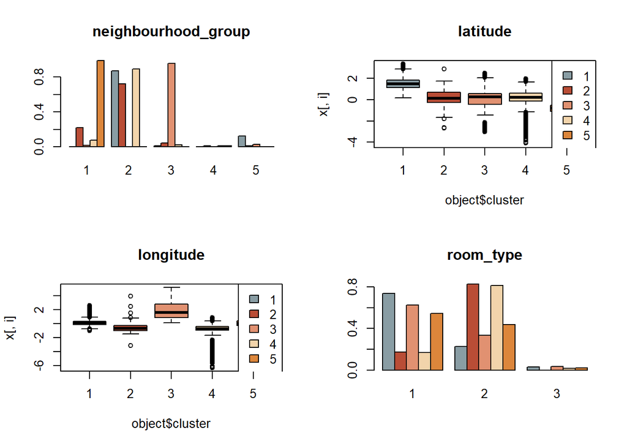

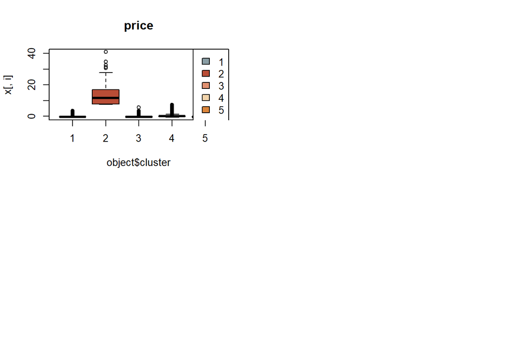

```r
library(wesanderson)
par(mfrow=c(2,2))
clprofiles(kp, dataset, col = wes_palette("Royal1",5, type = "continuous"))
```

```r
Es = numeric(10)
for(i in 1:10)
  {
    kpres <- kproto(dataset, k = i, nstart = 5)
    Es[i] <- kpres$tot.withinss
  }
```

[output not shown]

[output cut: 314 more lines]

[output not shown]

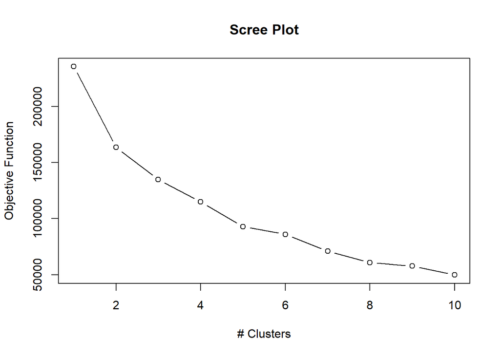

```r
plot(1:10, Es, type = "b", ylab = "Objective Function", xlab = "# Clusters",main = "Scree Plot")
```